# Midterm Project

Audrey Omidsalar

October 24, 2021

```r
if (!file.exists("Quarterly_Census_of_Employment_and_Wages__QCEW_.csv"))
  download.file(
    url = "https://data.edd.ca.gov/api/views/fisq-v939/rows.csv?accessType=DOWNLOAD",
    destfile = "Quarterly_Census_of_Employment_and_Wages__QCEW_.csv",
    method   = "libcurl",
    timeout  = 60
    )
input <- data.table::fread("Quarterly_Census_of_Employment_and_Wages__QCEW_.csv")
```

# Introduction

An issue that I have seen being constantly spoken about is the economy and the rise of inflation. Being a student in the science field, I have very little background on economics; frankly, the last time I took a course in economics was in high school. I was interested in examining wage disparities, more specifically throughout California, within the education sector and within colleges and universities, as this is the area I’m currently working in.

#### The question that I will be exploring is:

#### How have wages throughout California, in the education sector, and in Colleges and Universities changed from 2004 until 2020?

The dataset I used is California’s Quarterly Census of Employment and Wages from data.gov (https://catalog.data.gov/dataset/quarterly-census-of-employment-and-wages-qcew). It contains 4351631 rows and 15 columns, categorized by the following variables:

- Area type (county, state-wide, US; character data)
- Area name (name of county; character data)
- Year (2004 - 2021; integer data)
- Quarter (1st - 4th Quarter; character data)
- Ownership (state government, federal government, private; character data)
- NAICS (North American Industry Classification System) level (integer data)
- NAICS code (character data)
- Industry name (character data)
- Number of Establishments (integer data)
- Average monthly employment (integer data)
- 1st, 2nd and 3rd month employment (if there is a quarter designation; integer data)
- Total wages for all workers (numerical data)
- Average weekly wages (numerical data)

The specifications I was interested in looking in for this project were the average weekly wages throughout various counties in California, within the Education as a whole, and within the *Colleges and Universities* industry.

# Methods

The dataset was acquired from the data.gov database and can be downloaded using the following link: https://data.edd.ca.gov/api/views/fisq-v939/rows.csv?accessType=DOWNLOAD

It was downloaded as a csv (comma-separated values) file, and imported to Rstudio using the *data.table* package.

This dataset is quite large (531.5 MB), so I cleaned the data using the following steps:

1. I filtered the dataset to only include average annual wages. I did by looking at the column named *quarter*, which subdivides the data per each quarter (1st through 4th) as well as the annual values. In order to control for fluctuations throughout the year, I used the annual values for the subsequent steps. As a result, I removed the *1st, 2nd and 3rd Month Employment* columns as those have NA values when looking at annual data.
2. I omitted any nationwide observations (where the *Area Type* column was set to *United States*) to focus on California-specific observations only.
3. A smaller dataset (*education*) was made by subsetting the dataset by NAICS code values that begin with 61, which is the code for Education Services<sup>1</sup>.

The graphs in this report were made using the ggplot2 package.

#### Dependencies / Packages Used:

- data.table
- ggplot2
- dplyr
- tibble
- tidyverse

```r
#step 1
input <- filter(input, Quarter == "Annual")
#step 2
input <- filter(input, `Area Type` != "United States")
input = subset(input, select = -c(`1st Month Emp`,`2nd Month Emp`, `3rd Month Emp`) )
#step 3
education <- input %>% filter(str_detect(`NAICS Code`, '^61'))
```

# Results

### 1. Which industries have the highest and lowest wages?

To do this, I first searched for the median average weekly wage for each unique industry overall per year. I chose to look at the median rather than the mean in order to control for any outliers. There are likely industries that have seasonal changes, and I felt the median would be a fair estimation to compare. The top and bottom five industries are listed below.

```r
industries <- input[, .(
  median_wage = median(`Average Weekly Wages`, na.rm = TRUE)),
  by = .(`Industry Name`, Year)
]
```

The industries with the highest median wages include *all other information services* (this includes some big tech companies like Facebook, Linkedin and Yelp), *primary production of alumina and aluminum* (likely adjacent to the tech industry), *petrochemical manufacturing* (includes aerospace companies, making petroleum byproducts), *automobile manufacturing* (Tesla is likely a big contributor to this in California), and *credit card issuing*<sup>2</sup>.

```r
industries[order(-industries$median_wage), ] %>% head(5) %>% select(`Industry Name`, `Year`, median_wage) %>% knitr::kable(caption = "5 Industries with the Highest Median Weekly Wages per Year")
```

5 Industries with the Highest Median Weekly Wages per Year

| Industry Name | Year | median_wage |
| --- | --- | --- |
| All Other Information Services | 2020 | 8496.0 |
| Primary production of alumina and aluminum | 2019 | 6633.0 |
| Petrochemical Manufacturing | 2017 | 6529.0 |
| Automobile Manufacturing | 2020 | 5807.5 |
| Credit Card Issuing | 2018 | 5384.0 |

The industries with the lowest median wages are *mens underwear & nightwear manufacturing* (it is commonly known that fast fashion does not give liveable wages to many of its employees), *motion picture theaters, ex. Drive-Ins*, and *motion picture and video exhibition*. I would guess that these motion picture industries have a lot of fluctuations throughout the year and likely have high numbers of part-time employees, which would contribute to the low weekly wages. In addition, these observations are all from the two earliest years from this dataset; I would expect wages to increase yearly due to cost-of-living adjustments, so it makes sense why wages from 2004 and 2005 would be among the lowest.

```r
industries[order(industries$median_wage), ] %>% head(5) %>% select(`Industry Name`, `Year`, median_wage) %>% knitr::kable(caption = "5 Industries with the Lowest Median Weekly Wages per Year")
```

5 Industries with the Lowest Median Weekly Wages per Year

| Industry Name | Year | median_wage |
| --- | --- | --- |
| Mens Underwear & Nightwear Manufacturing | 2004 | 185.5 |
| Motion Picture Theaters, ex. Drive-Ins | 2004 | 193.0 |
| Motion Picture Theaters, ex. Drive-Ins | 2005 | 196.0 |
| Motion Picture and Video Exhibition | 2004 | 201.0 |
| Motion Picture and Video Exhibition | 2005 | 201.5 |

### 2. Which counties have the highest and lowest wages?

To do this, I found the median of the average weekly wage for each unique county per year. Again, I chose to look at the median rather than the mean in order to control for any outliers. The top and bottom five industries are listed below.

```r
counties <- input[, .(
  median_wage = median(`Average Weekly Wages`, na.rm = TRUE)),
  by = .(`Area Name`, Year)
]
```

San Francisco County, San Mateo County, and Santa Clara County have the highest median weekly wages overall. This makes sense given that there is a high cost of living in these areas and there are many high-paying tech-related industries in these areas. It also makes sense that the observations among the top 5 are from recent years, as I would expect salaries to increase yearly due to cost-of-living adjustments.

```r
counties[order(-counties$median_wage), ] %>% head(5) %>% select(`Area Name`, `Year`, median_wage) %>% knitr::kable(caption = "5 Counties with the Highest Median Weekly Wages per Year")
```

5 Counties with the Highest Median Weekly Wages per Year

| Area Name | Year | median_wage |
| --- | --- | --- |
| San Francisco County | 2020 | 1769.0 |
| San Francisco County | 2019 | 1603.0 |
| San Francisco County | 2018 | 1511.5 |
| San Mateo County | 2020 | 1461.0 |
| Santa Clara County | 2020 | 1432.0 |

The counties with the lowest median wages are Trinity County and Siskiyou County. These counties are located in more mountainous areas in Northern California near the Oregon border. The median wages being so low in these areas likely correspond to low population (Trinity County is the 4th least populated county in California) as well as seasonal jobs (likely more jobs in the winter months), and perhaps more part-time or volunteer workers since there are no major cities in these counties<sup>3</sup>.

```r
counties[order(counties$median_wage), ] %>% head(5) %>% select(`Area Name`, `Year`, median_wage) %>% knitr::kable(caption = "5 Counties with the Lowest Median Weekly Wages per Year")
```

5 Counties with the Lowest Median Weekly Wages per Year

| Area Name | Year | median_wage |
| --- | --- | --- |
| Trinity County | 2004 | 434 |
| Siskiyou County | 2004 | 441 |
| Siskiyou County | 2005 | 456 |
| Trinity County | 2006 | 458 |
| Trinity County | 2008 | 459 |

### 3. Which education sectors have the highest and lowest weekly wages?

I filtered the dataset to the top average weekly wages per industry. The top and bottom five are listed below.

```r
edsector <- education[, .(
  median_wage = median(`Average Weekly Wages`, na.rm = TRUE)),
  by = .(`Area Name`, Year, `Industry Name`)
]
```

The industries with the highest median wages are *Computer Training*, *Educational Support Services* and *Flight Training*. This makes sense to me given that the computer training category is tech-adjacent. I also know that flying is very costly, and educational support services (college counseling, standardized test preparation) can also be very costly.

```r
edsector[order(-edsector$median_wage), ] %>% head(5) %>% select(`Area Name`, `Industry Name`, `Year`, median_wage) %>% knitr::kable(caption = "Top 5 Median Weekly Wages per Year")
```

Top 5 Median Weekly Wages per Year

| Area Name | Industry Name | Year | median_wage |
| --- | --- | --- | --- |
| Sacramento County | Computer Training | 2017 | 2981 |
| Sonoma County | Educational Support Services | 2020 | 2890 |
| San Mateo County | Computer Training | 2016 | 2843 |
| San Mateo County | Computer Training | 2017 | 2784 |
| Solano County | Flight Training | 2020 | 2591 |

The industries with the lowest median wages are *Language Schools* and *Sports and Recreation Instruction*. Some contributing factors as to these low values are part-time and volunteer employees. The median wage of zero in Kings County means that either all the employees were volunteers (I do know that many of the sports leagues in communities have parents or older children volunteer to be coaches, so I didn’t feel comfortable removing this value) or there were errors in inputting this data.

```r
edsector[order(edsector$median_wage), ] %>% head(5) %>% select(`Area Name`, `Industry Name`, `Year`, median_wage) %>% knitr::kable(caption = "Bottom 5 Median Weekly Wages per Year")
```

Bottom 5 Median Weekly Wages per Year

| Area Name | Industry Name | Year | median_wage |
| --- | --- | --- | --- |
| Kings County | Sports and Recreation Instruction | 2004 | 0 |
| Yolo County | Language Schools | 2010 | 46 |
| Yolo County | Language Schools | 2011 | 49 |
| Yolo County | Language Schools | 2006 | 51 |
| Yolo County | Language Schools | 2012 | 52 |

The below table shows the highest weekly wages per industry in the *education* category (the top 5 are shown). One of the top industries mentioned earlier (*computer training*) is included here; however, the *Colleges and Universities* industry had the highest average weekly wage out of all the industries within the *education* sector. This makes sense to me given that this category likely encompasses universities with large endowments and high-salaried employees such as coaches for popular sports and the board of directors. Additionally, this industry will be the focus of the subsequent analysis; I was interested in looking at this in particular because I am a student worker at my university.

```r
topedsector <- education %>% group_by(`Industry Name`) %>% top_n(1, `Average Weekly Wages`)
topedsector[order(-topedsector$`Average Weekly Wages`), ] %>% head(5) %>% select(`Area Name`, `Industry Name`, `Year`, `Average Weekly Wages`) %>% knitr::kable(caption = "5 Education Sectors with the Highest Average Weekly Wages")
```

5 Education Sectors with the Highest Average Weekly Wages

| Area Name | Industry Name | Year | Average Weekly Wages |
| --- | --- | --- | --- |
| California | Colleges and Universities | 2019 | 3638 |
| California | Colleges and Universities | 2019 | 3638 |
| California | Colleges and Universities | 2019 | 3638 |
| Sacramento County | Computer Training | 2017 | 2981 |
| Sacramento County | Computer Training | 2017 | 2981 |

### 4. Within the *Colleges and Universities* sector, which counties have the highest salaries, and how much have salaries grown over the last decade?

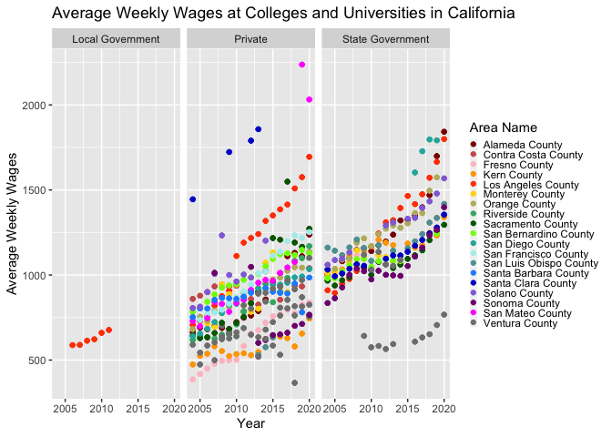

```r
colors <- c("Alameda County" = "#8B0000", "Contra Costa County" = "#CD5C5C", "Fresno County" = "#FFC0CB", "Kern County" = "#FFA500", "Los Angeles County" = "#FF4500", "Monterey County" = "#FFD700", "Orange County" = "#BDB76B", "Riverside County" = "#3CB371", "Sacramento County" = "#006400", "San Bernardino County" = "#7CFC00", "San Diego County" = "#20B2AA", "San Francisco County" = "#AFEEEE", "San Luis Obispo County" = "#5F9EA0", "Santa Barbara County" = "#1E90FF", "Santa Clara County" = "#0000CD", "Solano County" = "#9370DB", "Sonoma County" = "#800080", "San Mateo County" = "#FF00FF", "Ventura County" = "#808080")
colluniv <- filter(education, `Industry Name` == "Colleges and Universities")
colluniv[`Area Name` != "California"] %>% ggplot() +
  geom_point(mapping=aes(x=Year, y = `Average Weekly Wages`, group = `Area Name`, color=`Area Name`)) +
  labs(title = "Average Weekly Wages at Colleges and Universities in California", x  = "Year", y = "Average Weekly Wages") +
  theme(legend.key.size = unit(0.2,"cm"), legend.spacing = unit(0.1,"cm")) +
  facet_wrap(~Ownership) +
  scale_color_manual(values = colors)
```

To look more closely at how salary has grown, I calculated the percent changes (compared to the previous year reported) for privately owned and state government owned colleges and universities.

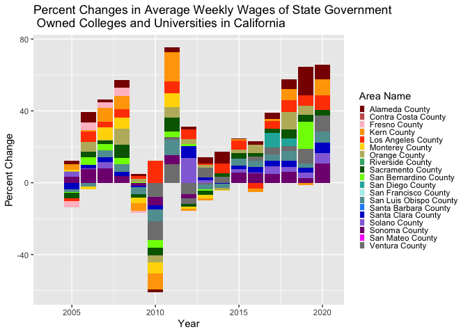

```r
statecolluniv <- colluniv[Ownership == "State Government"]
statecolluniv2 <- statecolluniv %>%
    group_by(`Area Name`) %>%
    arrange(Year) %>%
    mutate(pct.chg = 100 *(`Average Weekly Wages` - lag(`Average Weekly Wages`))/lag(`Average Weekly Wages`))
statecolluniv2 <- as.data.table(statecolluniv2)
statecolluniv2[!is.na(pct.chg) & `Area Name` != "California"] %>%
  ggplot() +
  geom_bar(mapping = aes(x = Year, y = pct.chg, fill = `Area Name`), stat ="identity") +
  labs(title = "Percent Changes in Average Weekly Wages of State Government \n Owned Colleges and Universities in California", y = "Percent Change") +
  scale_fill_manual(values = colors) +
  theme(legend.key.size = unit(0.2,"cm"), legend.spacing = unit(0.1,"cm"))
```

Below is the bar graph showing the percent changes for privately owned colleges and universities in California. Overall, I see more negative percent changes here compared to the previous graph, and this is likely due to the nature of these universities not having government regulation and having more autonomy with how they manage themselves. What stands out to me the most here is the positive percent change from 2018 to 2019 in San Mateo County. I believe Stanford University is the major private university in this county, and I found an article stating that their football coach David Shaw received “over 8.9 million in pay” in 2019, so this was likely a big contributor to the jump in average weekly wage for that year<sup>5</sup>.

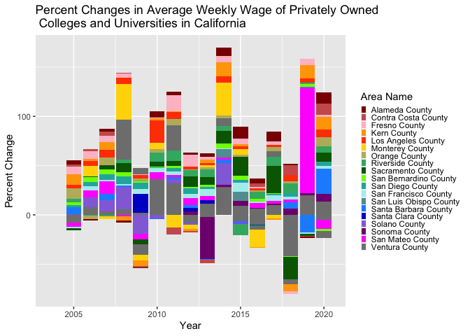

```r
privatecolluniv <- colluniv[Ownership == "Private"]
privatecolluniv2 <- privatecolluniv %>%
    group_by(`Area Name`) %>%
    arrange(Year) %>%
    mutate(pct.chg = 100 *(`Average Weekly Wages` - lag(`Average Weekly Wages`))/lag(`Average Weekly Wages`))
privatecolluniv2 <- as.data.table(privatecolluniv2)
privatecolluniv2[!is.na(pct.chg) & `Area Name` != "California"] %>%
  ggplot() +
  geom_bar(mapping = aes(x = Year, y = pct.chg, fill = `Area Name`), stat ="identity") +
  labs(title = "Percent Changes in Average Weekly Wage of Privately Owned \n Colleges and Universities in California", y = "Percent Change") +
  scale_fill_manual(values = colors) +
  theme(legend.key.size = unit(0.2,"cm"), legend.spacing = unit(0.1,"cm"))
```

# Conclusion

From this analysis, I have found that counties with major cities generally have higher wages than those that do not. Many of the top wages come from industries that are tech-related and are especially prevalent in the areas surrounding Silicon Valley. There is less county-wide variation in average weekly wages in colleges and universities owned by the state government compared to those that are privately owned. Colleges and universities that are owned by the state government also appear to be more likely to have positive percent changes in annual wage.

# References

1. “NAICS & Sic Identification Tools.” NAICS Association, https://www.naics.com/search/.
2. “NAICS Code: 519190 All Other Information Services.” NAICS Association, https://www.naics.com/naics-code-description/?code=519190.
3. “California Counties by Population.” California Outline, https://www.california-demographics.com/counties_by_population.
4. “Our Colleges.” LACCD Colleges, https://www.laccd.edu/about/pages/our-colleges.aspx.
5. Berkowitz, Steve. “Stanford Football Coach David Shaw Credited with More than $8.9 Million in Pay for 2019.” USA Today, Gannett Satellite Information Network, 4 Aug. 2021, https://www.usatoday.com/story/sports/ncaaf/pac12/2021/08/04/stanford-football-coach-david-shaw-2019-pay/5488869001/.